# Fit Damped Linear Oscillator model with OpenMx

Mar J.F Ollero- Autonomous University of Madrid, Spain

This page contains an illustrative example on how to fit the **Damped Linear Oscillator model** to a single individual’s negative affect measures. Note that this example was conceived as a supplementary material of Ollero, M. J. F., Estrada, E., Hunter, M. D., & Cáncer, P. F. (2023). Characterizing Affect Dynamics With a Damped Linear Oscillator Model: Theoretical Considerations and Recommendations for Individual-Level Applications. Psychological Methods. https://doi.org/10.1037/met0000615.

# Previous steps

*R* and *Rstudio* are needed and can be downloaded from [here](https://www.rstudio.com/products/rstudio/download/).

Once *R* and *Rstudio* are installed. *OpenMx* package is required, to install and load the package:

```r
install.packages ("OpenMx")
```

```r
library ("OpenMx")
```

# Data

The data used in this tutorial is available for download

here.

Now, to load the data and see the first lines of it:

```r
data <- read.table ("DLO_Tutorial_Individual.txt")
head (data)
```

```
##           y1     times id
## 1  3.1197310 0.2083333  1
## 2  0.9832255 0.2500000  1
## 3  1.2577379 1.3333333  1
## 4  0.6383892 1.5000000  1
## 5 -2.2059128 2.0833333  1
## 6 -1.9651488 2.2083333  1
```

The data set has 3 variables:

- **y1** is the score in negative affect at one point in time.
- **times** is the moment when the measurement occasion was collected. This data set contains two measurement occasions per day within the same 12 hours everyday. The individual was measured for 60 days.
- **id** is a variable that indicates to which subject the measurements correspond. This data belongs to one individual.

Here is a figure that depicts the scores of the individual under study over time:

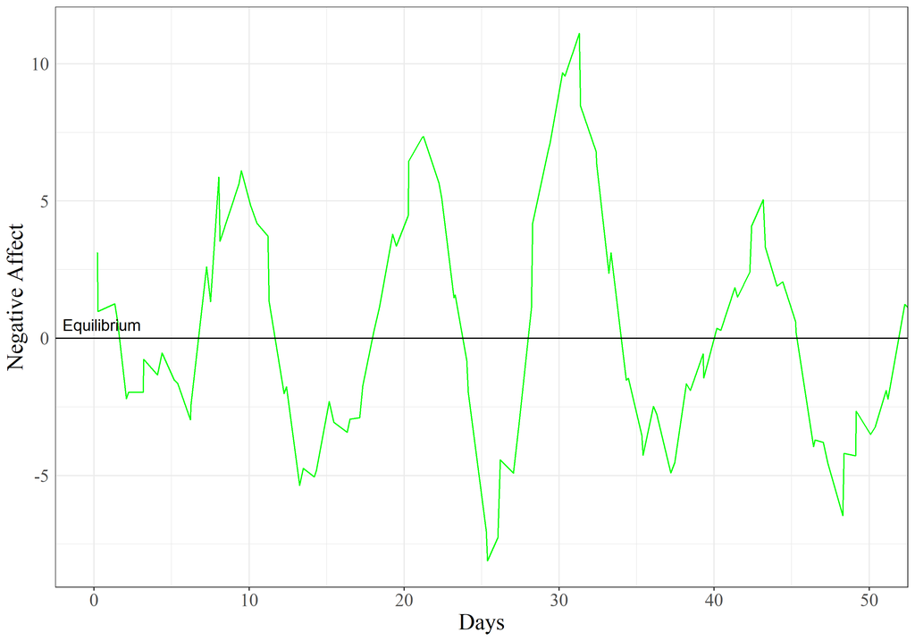

# Fit Damped Linear Oscillator

Now to estimate the Damped Linear Oscillator model, the following code is used:

```r
cdim <- list("y1", c('Position', 'Velocity'))
xdim <- 2
udim <- 1
ydim <- 1

# 1. Matrix of the latent part of the model

# Dynamics
amat <- mxMatrix('Full', xdim, xdim,
                 c(F, T, F, T), c(0, -.7, 1, -.3), name='A',
                 labels = c(NA, "eta", NA, "zeta"),
                 lbound = c (NA, -2, NA, -2),
                 ubound= c (NA, 0, NA, 0))

# Covariates
bmat <- mxMatrix('Full', xdim, udim,
                 c (F, F) , c (1,0), name='B')

# Dynamic Noise
qmat <- mxMatrix('Diag', xdim, xdim,
                 c(F,T), c(0,3), name='Q',
                 labels= c(NA, "q"),
                 lbound=1e-20)

#2. Matrix of the observed part of the model

# Factor loadings
cmat <- mxMatrix('Full', ydim, xdim,
                 c (F, F), values=c(1, 0), name='C', dimnames=cdim)
# Covariates
dmat <- mxMatrix('Zero', udim, udim, name='D')


# Measurement noise
rmat <- mxMatrix('Diag', ydim, ydim,
                 T , 0, name='R',
                 labels= c ("r"),
                 lbound=1e-20)

#3. Initial conditions
xmat <- mxMatrix('Full', xdim, 1,
                 c(T,F), c(0, 1), name='x0',
                 labels= c("ini", NA))

pmat <- mxMatrix('Diag', xdim, xdim,
                 F, 1, name='P0')

#4. Covariates
umat <- mxMatrix('Zero', udim, 1, name='u')

#5. Time
tmat <- mxMatrix('Full',
                 1, 1, name='time',
                 labels='data.times')

dlo <- mxModel("DampedLinearOscillator",
               amat, bmat, cmat, dmat, qmat, rmat, xmat, pmat, umat, tmat,
               mxExpectationStateSpaceContinuousTime('A', 'B', 'C', 'D',
                                                     'Q', 'R', 'x0', 'P0',
                                                     'u', t='time'),
               mxFitFunctionML())

dlod <- mxModel(dlo, mxData(data, 'raw'))
dlo_out <- mxRun(dlod)
```

And to access the results:

```r
summary(dlo_out)
```

```
## Summary of DampedLinearOscillator
##
## free parameters:
##   name matrix row col   Estimate  Std.Error A lbound ubound
## 1  eta      A   2   1 -0.3462620 0.04224325       -2      0
## 2 zeta      A   2   2 -0.1411505 0.08523968       -2      0
## 3    q      Q   2   2  1.8917314 0.79525644    1e-20
## 4    r      R   1   1  0.7343752 0.13180638    1e-20
## 5  ini     x0   1   1  1.9910718 1.18200434
##
## Model Statistics:
##                |  Parameters  |  Degrees of Freedom  |  Fit (-2lnL units)
##        Model:              5                    115              415.4067
##    Saturated:              2                    118                    NA
## Independence:              2                    118                    NA
## Number of observations/statistics: 120/120
##
## Information Criteria:
##       |  df Penalty  |  Parameters Penalty  |  Sample-Size Adjusted
## AIC:       185.4067               425.4067                 425.9330
## BIC:      -135.1549               439.3441                 423.5365
## CFI: NA
## TLI: 1   (also known as NNFI)
## RMSEA:  0  [95% CI (NA, NA)]
## Prob(RMSEA <= 0.05): NA
## To get additional fit indices, see help(mxRefModels)
## timestamp: 2023-09-22 13:51:00
## Wall clock time: 0.3579931 secs
## optimizer:  SLSQP
## OpenMx version number: 2.21.1
## Need help?  See help(mxSummary)
```

# References

Boker, S. M., Neale, M. C., Maes, H. H., Wilde, M. J., Spiegel, M., Brick, T. R., Estabrook, R., Bates, T. C., Mehta, P. D., von Oertzen, T., Gore, R. J., Hunter, M. D., & Hackett, D. C. (2018). OpenMx User Guide. https://openmx.ssri.psu.edu/documentation

Hunter, M. D. (2018). State Space Modeling in an Open Source, Modular, Structural Equation Modeling Environment. Structural Equation Modeling: A Multidisciplinary Journal, 25(2), 307-324. https://doi.org/10.1080/10705511.2017.1369354